# Estudo das relações das caractéristicas de um Parlamentar no Twitter

Igor Matheus Castor Diniz Pinheiro

```r
atividade = read_projectdata()

atividade = atividade %>%
  filter(seguidores > 0, n_proprio > 0, n_retweet > 0)

atividade = atividade  %>%
  filter(!is.na(twitter) & !is.na(segue)) %>%
  mutate(tuitou = !is.na(twitter) & (n_proprio + n_retweet > 0))

atividade = atividade %>% filter(!is.na(twitter))
```

# 1. Qual a relação entre as características da atuação do parlamentar e o engajamento total que ele obtém no twitter?

Por “características”, queremos dizer: qual a casa (senado/câmara) do parlamentar, quantas pessoas ele segue, por quantas ele é seguido, quanto ele tuíta e quanto ele retuíta.

## Análises

### Relação Seguidores vs. Engajamento total

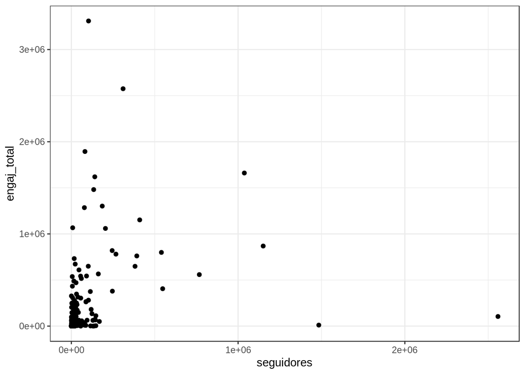

```r
atividade %>%
  ggplot(aes(x = seguidores, y = engaj_total)) +
  geom_point()
```

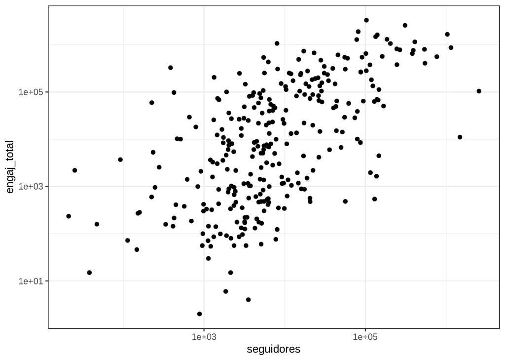

```r
atividade %>%
  ggplot(aes(x = seguidores, y = engaj_total)) +
  geom_point() +
  scale_y_log10() +
  scale_x_log10()
```

### Relação Casa vs. Engajamento total

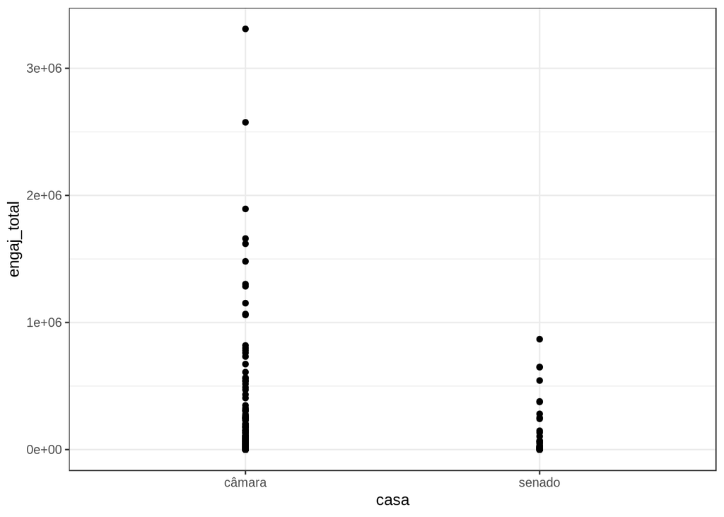

```r
atividade %>%
  ggplot(aes(x = casa, y = engaj_total)) +
  geom_point()
```

### Relação Pessoa que segue vs. Engajamento total

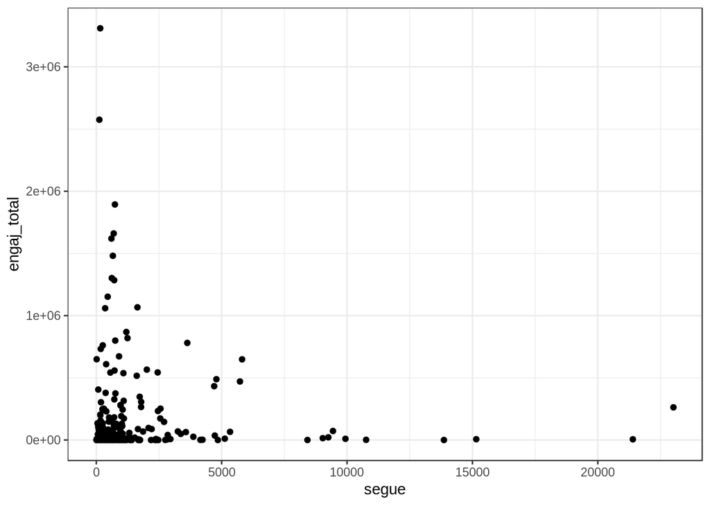

```r
atividade %>%
  ggplot(aes(x = segue, y = engaj_total)) +
  geom_point()
```

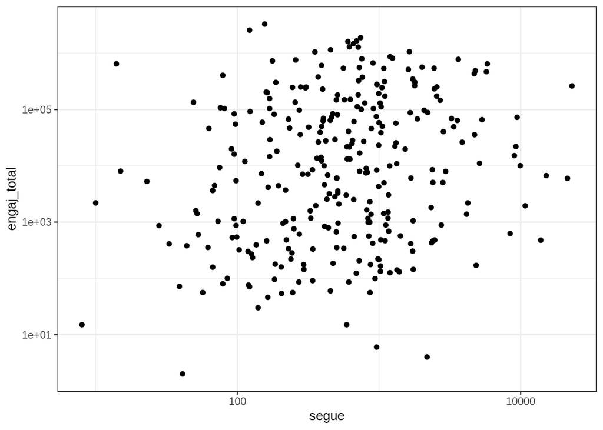

```r
atividade %>%
  ggplot(aes(x = segue, y = engaj_total)) +
  geom_point() +
  scale_y_log10() +
  scale_x_log10()
```

### Relação Twites próprios vs. Engajamento total

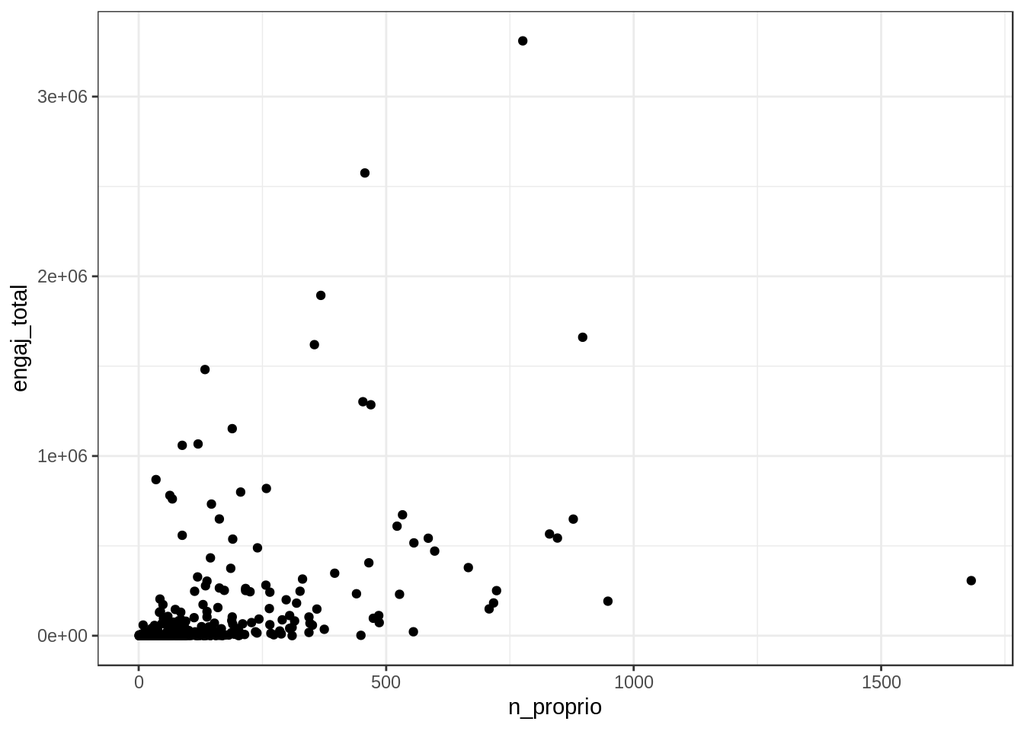

```r
atividade %>%
  ggplot(aes(x = n_proprio, y = engaj_total)) +
  geom_point()
```

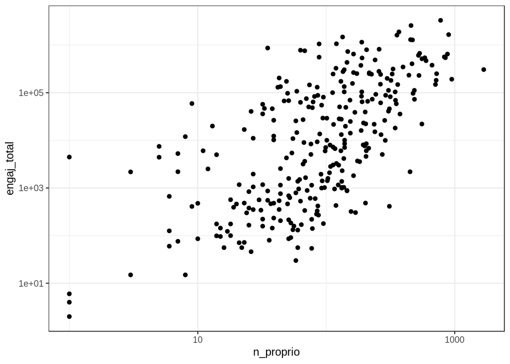

```r
atividade %>%
  ggplot(aes(x = n_proprio, y = engaj_total)) +
  geom_point() +
  scale_y_log10() +
  scale_x_log10()
```

### Relação Nº de Retweets vs. Engajamento total

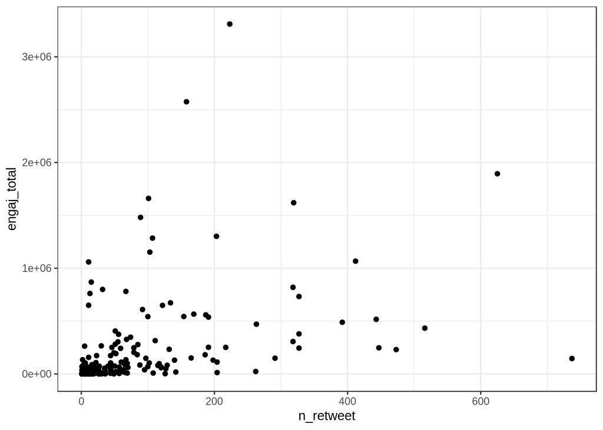

```r
atividade %>%
  ggplot(aes(x = n_retweet, y = engaj_total)) +
  geom_point()
```

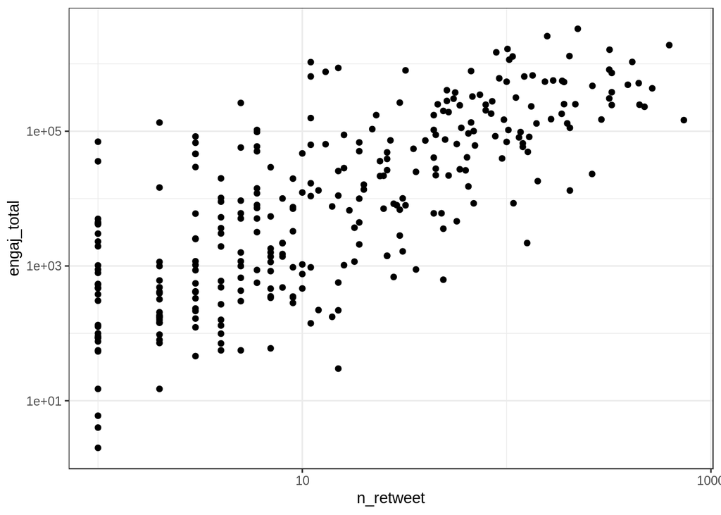

```r
atividade %>%
  ggplot(aes(x = n_retweet, y = engaj_total)) +
  geom_point() +
  scale_y_log10() +
  scale_x_log10()
```

Podemos perceber que para todas as Análises descritivas só foi possível perceber e compreender melhor o que estava acontecendo quand houve uma transformação para escala logarítimica, isso aconteceu porque dificilmente as relações do mundo são lineares.

## Criando o modelo

```r
atividade = atividade %>%
  mutate(seguidores_log = log10(seguidores),
         engaj_total_log = log10(engaj_total),
         segue_log = log10(segue),
         n_proprio_log = log10(n_proprio),
         n_retweet_log = log10(n_retweet))
```

```r
modelo = lm(engaj_total_log ~ seguidores_log + segue_log + n_proprio_log + n_retweet_log + casa,
   data = atividade)

tidy(modelo)
```

| term | estimate | std.error | statistic | p.value |
| --- | --- | --- | --- | --- |
| (Intercept) | 0.48652808 | 0.25514780 | 1.9068480 | 5.753177e-02 |
| seguidores_log | 0.56969096 | 0.05675132 | 10.0383741 | 1.544425e-20 |
| segue_log | -0.28193801 | 0.07592146 | -3.7135482 | 2.452250e-04 |
| n_proprio_log | 0.51475567 | 0.09898274 | 5.2004589 | 3.769707e-07 |
| n_retweet_log | 0.87607647 | 0.07381089 | 11.8692035 | 9.810965e-27 |
| casasenado | -0.05043997 | 0.10441463 | -0.4830738 | 6.294091e-01 |

```r
glance(modelo)
```

| r.squared | adj.r.squared | sigma | statistic | p.value | df | logLik | AIC | BIC | deviance | df.residual |
| --- | --- | --- | --- | --- | --- | --- | --- | --- | --- | --- |
| 0.7136951 | 0.7087417 | 0.706883 | 144.0827 | 2.60379e-76 | 6 | -313.2233 | 640.4467 | 666.2555 | 144.4085 | 289 |